# Using atacr for Enriched ATAC-seq analysis

Dan MacLean

2017-04-06

```r
devtools::load_all("~/Desktop/atacr")
```

```
## Loading atacr
```

*atacr* is a package, currently under development for creating statistics and diagnostic plots for short read sequence data from enriched ATAC-seq experiments.

The data `sim_counts` is a simulated data set with computer generated window counts for three replicates of each of two conditions in experiments with 500 bait and non-bait windows. We’ll set each experiment to have 10 % of windows differentially accessible at a difference of approximately 2 fold.

Counts in bait windows for “control” samples will be modelled as $C \sim NB(\mu = 30, size = 10\mu)$.

Counts in bait windows for “treatment” samples will be modelled as $C \cdot unif(0.8,1.2)$.

Differentially accessible bait windows will be modelled as $C_{1..50} \cdot \mathcal{N}( \mu=2,\sigma = \mu/2)$

The differentially accessible and bait windows will be the first 500 in the dataset, the non-bait windows will be the last 500.

## Basic experiment information

It’s very easy to get information on the coverage for bait/non-bait windows on a per sample basis

```r
summary(sim_counts)
```

```
## ATAC-seq experiment of 2 treatments in 6 samples
##  Treatments: control,treatment
##  Samples: control_001,control_002,control_003,treatment_001,treatment_002,treatment_003
##  Bait regions used: 500
##  Total Windows: 1000
##
##  On/Off target read counts:
##           sample off_target on_target percent_on_target
## 1   control_001        355  15001.00          97.68820
## 2   control_002        359  15170.00          97.68820
## 3   control_003        360  14976.00          97.65258
## 4 treatment_001        364  16665.77          97.86257
## 5 treatment_002        405  16755.63          97.63995
## 6 treatment_003        376  16640.31          97.79036
##  Quantiles:
##  $bait_windows
##     control_001 control_002 control_003 treatment_001 treatment_002
## 1%        18.99       18.00       18.00      16.99631      15.82787
## 5%        22.00       21.95       20.95      19.68127      21.01409
## 95%       40.00       40.00       39.00      61.10000      60.00000
## 99%       43.00       44.01       44.00     115.12000     113.04000
##     treatment_003
## 1%       15.67291
## 5%       19.27702
## 95%      62.10000
## 99%     111.03000
##
## $non_bait_windows
##     control_001 control_002 control_003 treatment_001 treatment_002
## 1%            0           0           0             0             0
## 5%            0           0           0             0             0
## 95%           3           4           3             4             4
## 99%           4           4           4             4             4
##     treatment_003
## 1%              0
## 5%              0
## 95%             4
## 99%             4
##
##  Read depths:
##           sample off_target on_target
## 1   control_001      0.710  30.00200
## 2   control_002      0.718  30.34000
## 3   control_003      0.720  29.95200
## 4 treatment_001      0.728  33.33155
## 5 treatment_002      0.810  33.51125
## 6 treatment_003      0.752  33.28062
```

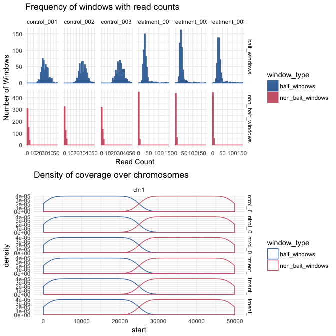

```r
plot(sim_counts)
```

These plots can be generated individually with the following functions

## QC Plots

Plot for coverage by sequence and sample

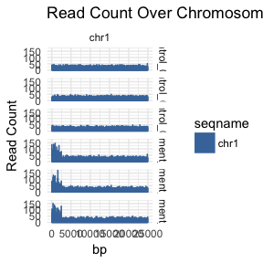

```r
plot_count_by_chromosome(sim_counts)
```

Correlations between sample counts

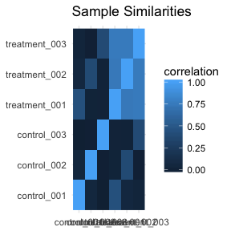

```r
sample_correlation_heatmap(sim_counts)
```

Count windows below a threshold.

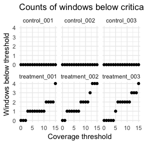

```r
windows_below_coverage_threshold_plot(sim_counts, which = "bait_windows", from=0, to=15)
```

MA plots

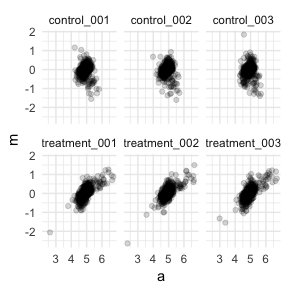

```r
ma_plot(sim_counts)
```

## Normalisation

Straightforward Library Size normalization, these returns a RangedSummarizedExperiment object

Can add this back to the object, and then use the `which` option of the plot objects to replot the new data

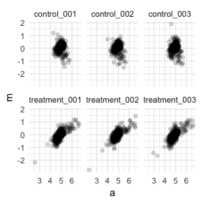

```r
sim_counts$library_size_normalised <- library_size_normalisation(sim_counts)
ma_plot(sim_counts, which = "library_size_normalised")
```

Normalisation by control windows. Requires a text file with the control window positions

```r
window_file <- "control_windows.txt"
sim_counts$control_window_normalisation <- control_window_normalise(sim_counts, window_file)
```

See csaw::offsetCalcs and normalisation vignettes.

## Detect differentially accessible windows

Using a bootstrap t-test method for simple two-way comparisons.

```r
result <- estimate_fdr(sim_counts, "control", "treatment", which = "bait_windows")
pander::pandoc.table(head(result))
```

Table continues below

| window | t | p_value | fdr | mean_count_a | mean_count_b | sd_a |
| --- | --- | --- | --- | --- | --- | --- |
| chr1:1-50:+ | -3.69 | 0 | 0 | 28.67 | 97.33 | 7.371 |
| chr1:51-100:- | -3.757 | 0 | 0 | 34 | 82.67 | 6.245 |
| chr1:101-150:- | -2.253 | 0 | 0 | 33.67 | 56.67 | 8.505 |
| chr1:151-200:+ | -4.549 | 0 | 0 | 33.33 | 81 | 10.6 |
| chr1:201-250:- | -2.292 | 0 | 0 | 31.67 | 45.33 | 4.509 |
| chr1:301-350:- | -5.567 | 0 | 0 | 30.67 | 121.7 | 7.506 |

| sd_b | log2_fold_change | is_sig |
| --- | --- | --- |
| 31.37 | -1.764 | TRUE |
| 21.55 | -1.282 | TRUE |
| 15.5 | -0.7512 | TRUE |
| 14.73 | -1.281 | TRUE |
| 9.292 | -0.5176 | TRUE |
| 27.3 | -1.988 | TRUE |